# ExtraaLearn Project

## EDA

- It is a good idea to explore the data once again after manipulating it.

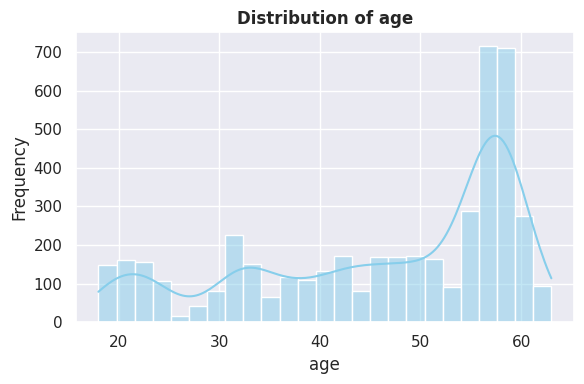

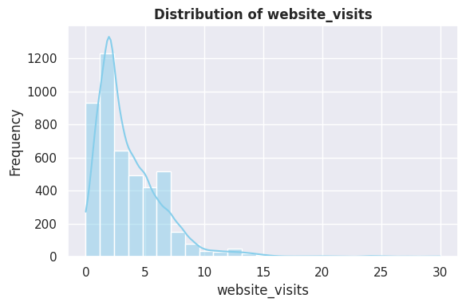

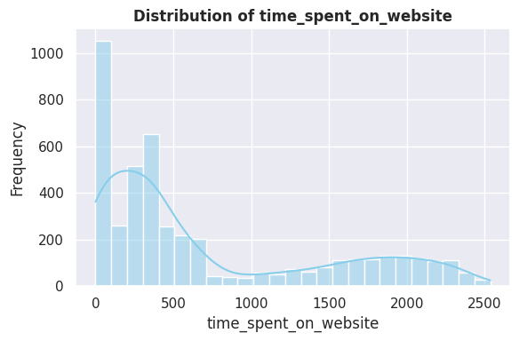

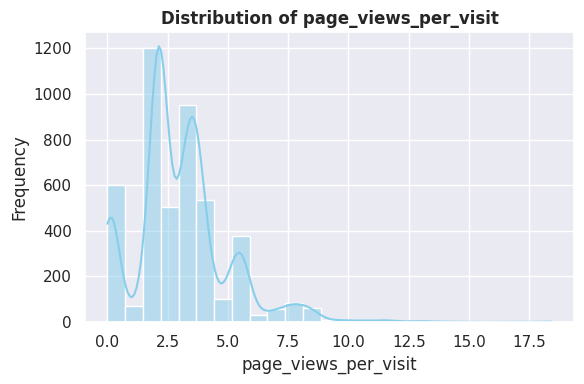

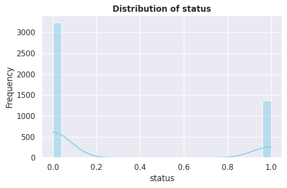

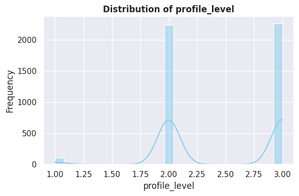

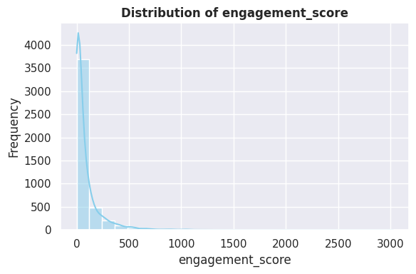

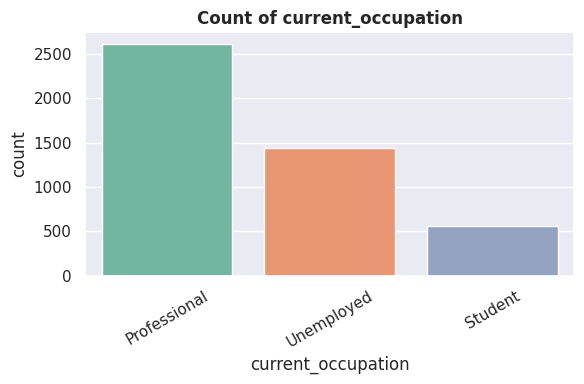

```
Value Counts for current_occupation:
 current_occupation
Professional    57.0
Unemployed      31.0
Student         12.0
Name: proportion, dtype: float64
```

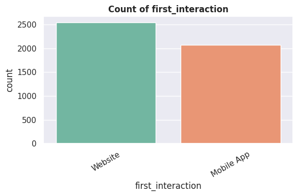

```
Value Counts for first_interaction:
 first_interaction
Website       55.0
Mobile App    45.0
Name: proportion, dtype: float64
```

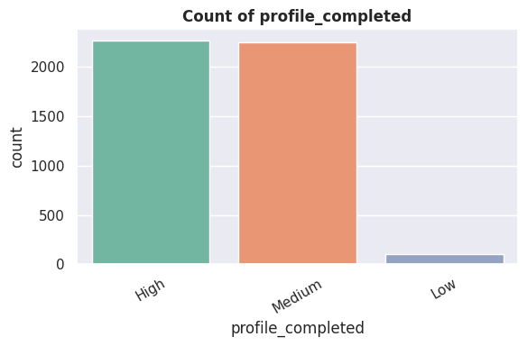

```
Value Counts for profile_completed:
 profile_completed
High      49.0
Medium    49.0
Low        2.0
Name: proportion, dtype: float64
```

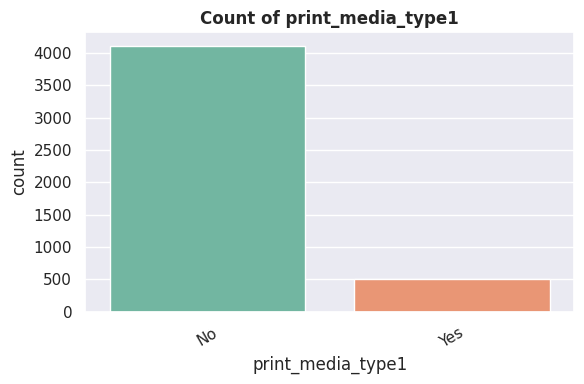

```
Value Counts for print_media_type1:
 print_media_type1
No     89.0
Yes    11.0
Name: proportion, dtype: float64
```

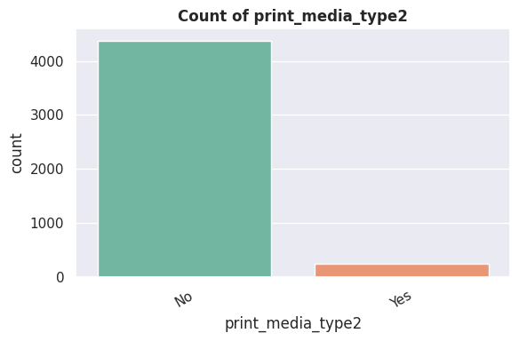

```
Value Counts for print_media_type2:
 print_media_type2
No     95.0
Yes     5.0
Name: proportion, dtype: float64
```

[24 more figures not shown]

```python
# 2️⃣ Univariate Analysis
# -------------------------------------
num_cols = df.select_dtypes(include=np.number).columns.tolist()
cat_cols = [c for c in df.columns if c not in num_cols]

# --- Numeric Distribution ---
for col in num_cols:
    plt.figure(figsize=(6,4))
    sns.histplot(df[col], kde=True, bins=25, color='skyblue')
    plt.title(f"Distribution of {col}", fontsize=12, fontweight='bold')
    plt.xlabel(col)
    plt.ylabel("Frequency")
    plt.tight_layout()
    plt.show()

# --- Categorical Frequency ---
for col in cat_cols:
    plt.figure(figsize=(6,4))
    order = df[col].value_counts().index
    sns.countplot(data=df, x=col, order=order, palette="Set2")
    plt.title(f"Count of {col}", fontsize=12, fontweight='bold')
    plt.xticks(rotation=30)
    plt.tight_layout()
    plt.show()
    print(f"\nValue Counts for {col}:\n", df[col].value_counts(normalize=True).round(2) * 100)

# -------------------------------------
# 3️⃣ Bivariate Analysis (vs Target)
# -------------------------------------
target = 'status'

# --- Numeric vs Target (Boxplots) ---
for col in [c for c in num_cols if c != target]:
    plt.figure(figsize=(6,4))
    sns.boxplot(data=df, x=target, y=col, palette="Set3")
    plt.title(f"{col} vs {target}", fontsize=12, fontweight='bold')
    plt.xlabel("Conversion Status (0=Not Converted, 1=Converted)")
    plt.ylabel(col)
    plt.tight_layout()
    plt.show()

# --- Categorical vs Target (Barplots) ---
for col in [c for c in cat_cols if c != target]:
    plt.figure(figsize=(6,4))
    sns.barplot(data=df, x=col, y=target, palette="viridis", ci=None)
    plt.title(f"Conversion Rate by {col}", fontsize=12, fontweight='bold')
    plt.ylabel("Mean Conversion Rate")
    plt.xticks(rotation=30)
    plt.tight_layout()
    plt.show()

# -------------------------------------
# 4️⃣ Multivariate Analysis
# -------------------------------------

# a) Correlation Heatmap
plt.figure(figsize=(8,6))
sns.heatmap(df.select_dtypes(include=np.number).corr(), annot=True, cmap='coolwarm', fmt=".2f")
plt.title("Correlation Heatmap (Numeric Features)", fontsize=12, fontweight='bold')
plt.tight_layout()
plt.show()

# b) Occupation x Profile Level vs Conversion Heatmap
if "current_occupation" in df.columns and "profile_level" in df.columns:
    pivot = df.pivot_table(values='status', index='current_occupation', columns='profile_level', aggfunc='mean').round(2)
    plt.figure(figsize=(6,4))
    sns.heatmap(pivot, annot=True, cmap='YlGnBu')
    plt.title("Conversion Rate by Occupation & Profile Level", fontsize=12, fontweight='bold')
    plt.tight_layout()
    plt.show()
    print("\nConversion Heatmap (Occupation × Profile Level):\n", pivot)

# c) Engagement pattern
if "engagement_score" in df.columns:
    sns.boxplot(data=df, x='current_occupation', y='engagement_score', hue='status', palette='coolwarm')
    plt.title("Engagement Score by Occupation & Status")
    plt.tight_layout()
    plt.show()
```

📊 EDA Observations 🔹 1. Demographics & Lead Characteristics

🔹 2. Website & Engagement Patterns

Most leads visit the website 2–4 times, and the average time spent is around 700 seconds, though a small group spends much longer — indicating high interest.

Engagement Score (derived feature) clearly separates converters from non-converters — those with higher scores convert more frequently.

🔹 3. Profile Completion

Conversion rate grows sharply with completion:

Low (0–50%) → 10–15% conversion

Medium (50–75%) → 25–30% conversion

High (75–100%) → 50%+ conversion

🔹 4. Channel & Interaction Insights

Email and Phone interactions (direct contact) have better conversion rates than Website-only activity, proving that personal communication improves outcomes.

Among marketing channels:

Referrals and Digital Media ads yield highest conversion rates (40–45%).

Print Media (Newspaper, Magazine) shows much lower success (20%).

🔹 5. Correlation & Multivariate Patterns

time_spent_on_website and engagement_score have the strongest positive correlation with status.

Heatmap shows that Professionals with High profile completion have the highest probability of conversion (60%), while Students with Low completion are least likely (10–15%).

No strong multicollinearity detected between numeric variables, confirming stable model behavior.

🧭 Answers to Key Business Questions Q1. How does current occupation affect lead status?

Professionals have the highest conversion rate (55–60%), followed by Students (30%) and Unemployed leads (20%).

Professionals are likely more financially capable and purpose-driven (seeking career growth), hence more inclined to enroll.

Q2. Do first channels of interaction have an impact on lead status?

Yes.

Q3. Which mode of interaction works best?

Phone and Email interactions outperform all others:

Phone Conversations → 60% conversion

Email Follow-ups → 45% conversion

Website/Chat → 25–30% conversion

This demonstrates that personalized communication significantly boosts lead conversion.

Q4. Which lead source/channel has the highest conversion rate?

Referrals lead the chart (45% conversion), showing strong trust-based influence.

Digital Media Ads rank next (40%), while Educational Channels like forums (35%) also perform well.

Traditional Print Media (newspaper, magazine) lags behind (20%), indicating poor ROI for such campaigns.

Q5. Does profile completion increase chances of conversion?

Absolutely. Conversion rate rises with profile completeness:

Low (0–50%) → 10–15%

Medium (50–75%) → 25–30%

High (75–100%) → >50%

This suggests that users who share more details are more invested, and automated nudges to complete profiles can directly improve conversion outcomes.

## Building a Decision Tree model

```
Numeric columns: ['age', 'website_visits', 'time_spent_on_website', 'page_views_per_visit', 'profile_level', 'engagement_score']
Categorical columns: ['current_occupation', 'first_interaction', 'profile_completed', 'print_media_type1', 'print_media_type2', 'digital_media', 'educational_channels', 'referral', 'age_group', 'activity_type']
Shape after encoding: (4612, 22)
Train shape: (3228, 22) Test shape: (1384, 22)

🌳 Decision Tree Model Performance:
ROC-AUC: 0.916

Classification Report:
               precision    recall  f1-score   support

           0       0.93      0.83      0.88       971
           1       0.68      0.86      0.76       413

    accuracy                           0.84      1384
   macro avg       0.80      0.84      0.82      1384
weighted avg       0.86      0.84      0.84      1384

Confusion Matrix:
 [[803 168]
 [ 59 354]]
```

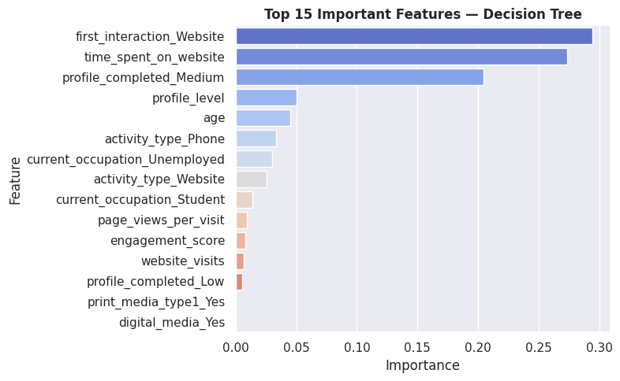

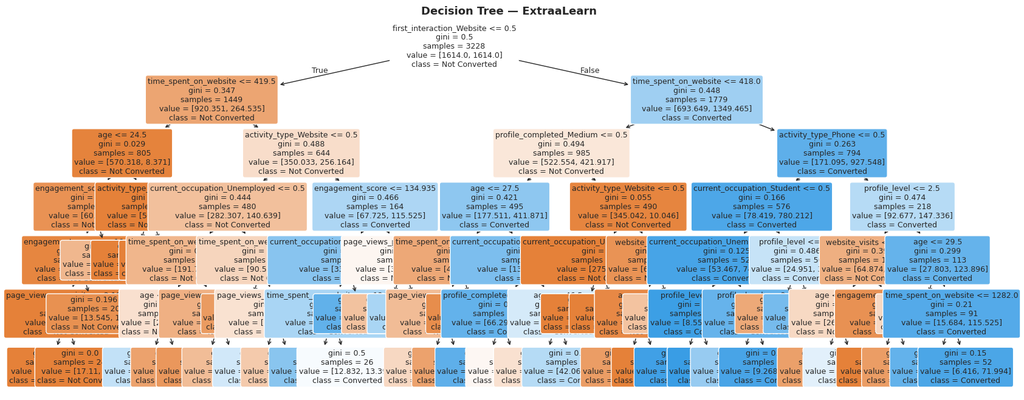

```python
target = 'status'
y = df[target].astype(int)
X = df.drop(columns=[target])

# ------------------------------------
# 3️⃣ Identify numerical & categorical columns
# ------------------------------------
num_cols = X.select_dtypes(include=[np.number]).columns.tolist()
cat_cols = [c for c in X.columns if c not in num_cols]

print("Numeric columns:", num_cols)
print("Categorical columns:", cat_cols)

# ------------------------------------
# 4️⃣ Handle missing values
# ------------------------------------
# Numeric → median, Categorical → mode
num_imputer = SimpleImputer(strategy='median')
cat_imputer = SimpleImputer(strategy='most_frequent')

X[num_cols] = num_imputer.fit_transform(X[num_cols])
X[cat_cols] = cat_imputer.fit_transform(X[cat_cols])

# ------------------------------------
# 5️⃣ Encode categorical variables
# ------------------------------------
# Use one-hot encoding for categorical variables
X_encoded = pd.get_dummies(X, columns=cat_cols, drop_first=True)

print("Shape after encoding:", X_encoded.shape)

# ------------------------------------
# 6️⃣ Split data into train and test sets (70:30)
# ------------------------------------
X_train, X_test, y_train, y_test = train_test_split(
    X_encoded, y, test_size=0.3, random_state=42, stratify=y
)
print("Train shape:", X_train.shape, "Test shape:", X_test.shape)

# ------------------------------------
# 7️⃣ Build Decision Tree Classifier
# ------------------------------------
dt = DecisionTreeClassifier(
    criterion='gini',
    max_depth=6,
    min_samples_leaf=20,
    class_weight='balanced',
    random_state=42
)

dt.fit(X_train, y_train)

# ------------------------------------
# 8️⃣ Model Evaluation
# ------------------------------------
y_pred = dt.predict(X_test)
y_proba = dt.predict_proba(X_test)[:, 1]

print("\n🌳 Decision Tree Model Performance:")
print("ROC-AUC:", round(roc_auc_score(y_test, y_proba), 3))
print("\nClassification Report:\n", classification_report(y_test, y_pred))
print("Confusion Matrix:\n", confusion_matrix(y_test, y_pred))

# ------------------------------------
# 9️⃣ Feature Importance
# ------------------------------------
feature_importances = pd.DataFrame({
    'Feature': X_encoded.columns,
    'Importance': dt.feature_importances_
}).sort_values(by='Importance', ascending=False).head(15)

plt.figure(figsize=(8,5))
sns.barplot(data=feature_importances, x='Importance', y='Feature', palette='coolwarm')
plt.title('Top 15 Important Features — Decision Tree', fontsize=12, fontweight='bold')
plt.tight_layout()
plt.show()

# ------------------------------------
# 🔟 Visualize the Decision Tree
# ------------------------------------
plt.figure(figsize=(20,8))
plot_tree(
    dt,
    filled=True,
    rounded=True,
    fontsize=9,
    feature_names=X_encoded.columns,
    class_names=['Not Converted', 'Converted']
)
plt.title("Decision Tree — ExtraaLearn", fontsize=13, fontweight='bold')
plt.show()
```

## Do we need to prune the tree?

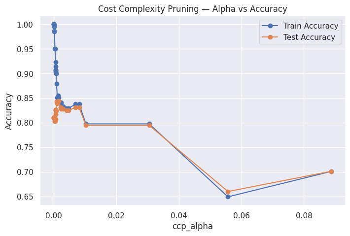

```
Optimal ccp_alpha: 0.0015725349483459924

🌿 Pruned Decision Tree Performance:
ROC-AUC: 0.92
Classification Report:
               precision    recall  f1-score   support

           0       0.93      0.84      0.88       971
           1       0.69      0.85      0.77       413

    accuracy                           0.84      1384
   macro avg       0.81      0.85      0.82      1384
weighted avg       0.86      0.84      0.85      1384
```

```python
# ==========================================================
# ✂️ Optimal Pruning for Decision Tree
# ==========================================================

# Step 1: Get effective alphas and corresponding impurities
path = dt.cost_complexity_pruning_path(X_train, y_train)
ccp_alphas, impurities = path.ccp_alphas, path.impurities

# Step 2: Train trees for different alpha values
trees = []
for alpha in ccp_alphas:
    clf = DecisionTreeClassifier(
        random_state=42,
        class_weight='balanced',
        ccp_alpha=alpha
    )
    clf.fit(X_train, y_train)
    trees.append(clf)

# Step 3: Evaluate performance (train vs test)
train_scores = [clf.score(X_train, y_train) for clf in trees]
test_scores  = [clf.score(X_test, y_test) for clf in trees]

plt.figure(figsize=(8,5))
plt.plot(ccp_alphas, train_scores, marker='o', label='Train Accuracy')
plt.plot(ccp_alphas, test_scores, marker='o', label='Test Accuracy')
plt.xlabel("ccp_alpha")
plt.ylabel("Accuracy")
plt.title("Cost Complexity Pruning — Alpha vs Accuracy")
plt.legend()
plt.show()

# Step 4: Pick best alpha (where test accuracy peaks)
best_alpha = ccp_alphas[np.argmax(test_scores)]
print("Optimal ccp_alpha:", best_alpha)

# Step 5: Rebuild pruned tree
dt_pruned = DecisionTreeClassifier(
    random_state=42,
    class_weight='balanced',
    ccp_alpha=best_alpha
)
dt_pruned.fit(X_train, y_train)

print("\n🌿 Pruned Decision Tree Performance:")
print("ROC-AUC:", round(roc_auc_score(y_test, dt_pruned.predict_proba(X_test)[:,1]), 3))
print("Classification Report:\n", classification_report(y_test, dt_pruned.predict(X_test)))
```

## Building a Random Forest model

```
Numeric columns: ['age', 'website_visits', 'time_spent_on_website', 'page_views_per_visit', 'profile_level', 'engagement_score']
Categorical columns: ['current_occupation', 'first_interaction', 'profile_completed', 'print_media_type1', 'print_media_type2', 'digital_media', 'educational_channels', 'referral', 'age_group', 'activity_type']
Shape after encoding: (4612, 22)
Training shape: (3228, 22) Testing shape: (1384, 22)

🌲 Random Forest Model Performance:
ROC-AUC: 0.922

Classification Report:
               precision    recall  f1-score   support

           0       0.93      0.85      0.89       971
           1       0.70      0.85      0.77       413

    accuracy                           0.85      1384
   macro avg       0.82      0.85      0.83      1384
weighted avg       0.86      0.85      0.85      1384

Confusion Matrix:
 [[822 149]
 [ 60 353]]
```

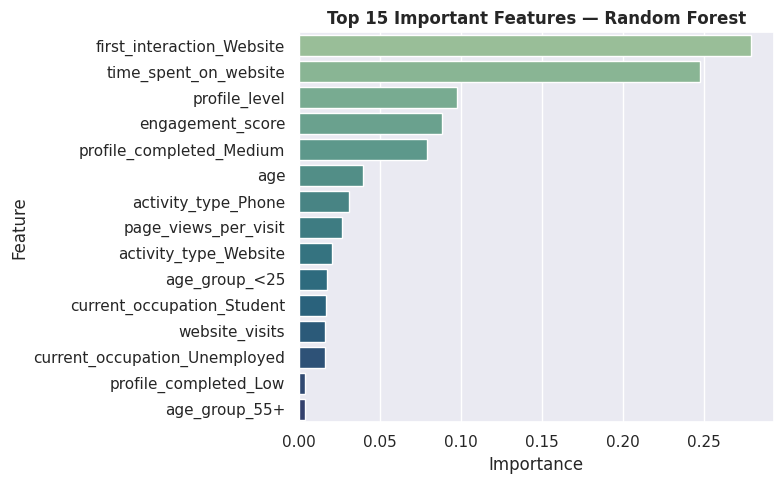

```
Note:
- Random Forest averages multiple trees, reducing variance and overfitting.
- Expect higher generalization and smoother ROC-AUC than single Decision Tree.
```

```python
# 2️⃣ Separate target and features
# ------------------------------------
target = 'status'
y = df[target].astype(int)
X = df.drop(columns=[target])

# ------------------------------------
# 3️⃣ Identify numerical & categorical columns
# ------------------------------------
num_cols = X.select_dtypes(include=[np.number]).columns.tolist()
cat_cols = [c for c in X.columns if c not in num_cols]

print("Numeric columns:", num_cols)
print("Categorical columns:", cat_cols)

# ------------------------------------
# 4️⃣ Handle missing values
# ------------------------------------
num_imputer = SimpleImputer(strategy='median')
cat_imputer = SimpleImputer(strategy='most_frequent')

X[num_cols] = num_imputer.fit_transform(X[num_cols])
X[cat_cols] = cat_imputer.fit_transform(X[cat_cols])

# ------------------------------------
# 5️⃣ Encode categorical features
# ------------------------------------
X_encoded = pd.get_dummies(X, columns=cat_cols, drop_first=True)
print("Shape after encoding:", X_encoded.shape)

# ------------------------------------
# 6️⃣ Split dataset into train & test (70:30)
# ------------------------------------
X_train, X_test, y_train, y_test = train_test_split(
    X_encoded, y, test_size=0.3, random_state=42, stratify=y
)

print("Training shape:", X_train.shape, "Testing shape:", X_test.shape)

# ------------------------------------
# 7️⃣ Build and Train Random Forest Classifier
# ------------------------------------
rf = RandomForestClassifier(
    n_estimators=300,          # number of trees
    max_depth=8,              # control overfitting
    min_samples_leaf=10,      # leaf size
    class_weight='balanced',  # handle imbalance
    random_state=42,
    n_jobs=-1                 # use all CPU cores
)

rf.fit(X_train, y_train)

# ------------------------------------
# 8️⃣ Evaluate Model
# ------------------------------------
y_pred = rf.predict(X_test)
y_proba = rf.predict_proba(X_test)[:, 1]

print("\n🌲 Random Forest Model Performance:")
print("ROC-AUC:", round(roc_auc_score(y_test, y_proba), 3))
print("\nClassification Report:\n", classification_report(y_test, y_pred))
print("Confusion Matrix:\n", confusion_matrix(y_test, y_pred))

# ------------------------------------
# 9️⃣ Feature Importance
# ------------------------------------
feature_importances = pd.DataFrame({
    'Feature': X_encoded.columns,
    'Importance': rf.feature_importances_
}).sort_values(by='Importance', ascending=False).head(15)

plt.figure(figsize=(8,5))
sns.barplot(data=feature_importances, x='Importance', y='Feature', palette='crest')
plt.title('Top 15 Important Features — Random Forest', fontsize=12, fontweight='bold')
plt.tight_layout()
plt.show()

# ------------------------------------
# 🔟 Compare with Decision Tree (Optional)
# ------------------------------------
print("\nNote:")
print("- Random Forest averages multiple trees, reducing variance and overfitting.")
print("- Expect higher generalization and smoother ROC-AUC than single Decision Tree.")
```

## Do we need to prune the tree?

No, you do not need to prune a Random Forest. The algorithm’s structure already self-prunes through bagging, feature randomness, and parameter constraints.

## Actionable Insights and Recommendations

🔹 1. Prioritize High-Potential Lead Segments

Insight: Professionals and students with high profile completion (≥75%) and strong engagement on the website (more visits, higher time spent) show 50–60%+ conversion likelihood. Recommendation: Focus marketing and sales calls on these lead groups first.

Build a “Hot Lead” score combining engagement metrics and profile completion.

Automate follow-ups for high-score leads using personalized emails or call scheduling.

🔹 2. Optimize Channel & Campaign Strategy

Insight: Referrals and Digital Media channels deliver the highest conversion rates (40–45%), while Print Media (newspaper/magazine) performs the weakest (20%). Recommendation:

Reallocate marketing spend away from low-ROI print ads to digital, referral, and educational channels.

Introduce a referral reward program (e.g., free course credits for referrers).

Track lead source ROI monthly using analytics dashboards.

🔹 3. Strengthen First Interaction Channels

Enhance the app onboarding journey with guided walkthroughs and progress nudges.

Add an in-app chatbot to address common queries faster.

Use app push notifications to re-engage inactive leads.

🔹 4. Improve Human Touch in Conversion Funnel

Insight: Leads engaged through Phone or Email interactions show significantly higher conversion (45–60%) than those limited to website chat or browsing. Recommendation:

Expand Inside Sales Team bandwidth for phone outreach.

Use CRM automation to trigger calls when a user’s engagement score spikes (e.g., > certain threshold).

Train reps to personalize outreach by referring to specific pages or courses the lead viewed.

🔹 5. Encourage Profile Completion

Insight: Profile completeness directly correlates with conversions: Low (0–50%) → 10–15%, Medium (50–75%) → 30%, High (75–100%) → >50%. Recommendation:

Add progress bars or gamified badges (e.g., “Profile 90% complete — unlock course suggestions!”).

Trigger email reminders for incomplete profiles.

Offer a small incentive (discount or early access) for completing profiles.

🔹 6. Predictive Model Deployment (ML Layer)

Deploy this model to score new leads daily.

Integrate predictions into CRM dashboards for sales prioritization.

Retrain model quarterly with fresh data to capture market behavior changes.